# DAND Final project: Bike sharing

# Exploratory analysis.

### (Includes data wrangling)

#### part of Udacity Data Analyst formation, May 2020, v3

##### By Mauricio Cabreira

```python
## Table of Contents
- [Introduction](#intro)
- [The Data](#data)
- [Data Wrangling](#wrangling)
- [Cleaning data](#cleaning)
- [Exploratory Analysis](#exploratory)
```

# Introduction

Bay Area Bike Share (now Ford GoBike) provides on-demand bike rentals for customers in San Francisco, Redwood City, Palo Alto, Mountain View, and San Jose. Users can unlock bikes from various stations throughout each city, and return them to any station within the same city. Clients pay for the service either through a yearly subscription or by purchasing a 24-hour or 3-day pass. Under service conditions, they can make an unlimited number of trips: trips under thirty minutes in length have no additional charge, longer trips will incur overtime fees.

# The Data

### All 2019 trips are part of this exploratory analysis

**Each trip is anonymized and includes:**

Trip Duration (seconds)

Start: time, station id, station latitude/longitude,

End: time, station id, station latitude/longitude,

Bike ID

User Type (Subscriber or Customer – “Subscriber” = Member or “Customer” = Casual)

# Data Wrangling

## Gathering Data

The data is loaded manually from 12 files, where each file contains a month of the year. They will be combined into a single datafile (df).

```python
#Import needed packages

import pandas as pd
import numpy as np
import matplotlib.pyplot as plt
%matplotlib inline
import requests
import tweepy
import time
import json
import seaborn as sns
import math
from datetime import datetime
from functools import reduce

from functions import haversine2
from functions_for_this_analysis import haversine
```

```python
print("Now =", datetime.now().strftime("%H:%M:%S"))
df_jan_2019 = pd.read_csv('../final_project_original_data_files/201901-fordgobike-tripdata.csv')

print("Now =", datetime.now().strftime("%H:%M:%S"))
df_feb_2019 = pd.read_csv('../final_project_original_data_files/201902-fordgobike-tripdata.csv')
print("Now =", datetime.now().strftime("%H:%M:%S"))

df_mar_2019 = pd.read_csv('../final_project_original_data_files/201903-fordgobike-tripdata.csv')
print("Now =", datetime.now().strftime("%H:%M:%S"))

df_apr_2019 = pd.read_csv('../final_project_original_data_files/201904-fordgobike-tripdata.csv')
print("Now =", datetime.now().strftime("%H:%M:%S"))

df_may_2019 = pd.read_csv('../final_project_original_data_files/201905-baywheels-tripdata.csv')
print("Now =", datetime.now().strftime("%H:%M:%S"))

df_jun_2019 = pd.read_csv('../final_project_original_data_files/201906-baywheels-tripdata.csv')
print("Now =", datetime.now().strftime("%H:%M:%S"))

df_jul_2019 = pd.read_csv('../final_project_original_data_files/201907-baywheels-tripdata.csv')
print("Now =", datetime.now().strftime("%H:%M:%S"))

df_aug_2019 = pd.read_csv('../final_project_original_data_files/201908-baywheels-tripdata.csv')
print("Now =", datetime.now().strftime("%H:%M:%S"))

df_sep_2019 = pd.read_csv('../final_project_original_data_files/201909-baywheels-tripdata.csv')
print("Now =", datetime.now().strftime("%H:%M:%S"))

df_oct_2019 = pd.read_csv('../final_project_original_data_files/201910-baywheels-tripdata.csv')
print("Now =", datetime.now().strftime("%H:%M:%S"))

df_nov_2019 = pd.read_csv('../final_project_original_data_files/201911-baywheels-tripdata.csv')
print("Now =", datetime.now().strftime("%H:%M:%S"))

df_dec_2019 = pd.read_csv('../final_project_original_data_files/201912-baywheels-tripdata.csv')
print("Now =", datetime.now().strftime("%H:%M:%S"))
```

```
Now = 09:31:45
Now = 09:31:45
Now = 09:31:46
Now = 09:31:47
Now = 09:31:48
Now = 09:31:48
```

```
Now = 09:31:49
```

```
Now = 09:31:50
Now = 09:31:51
Now = 09:31:52
Now = 09:31:53
Now = 09:31:54
Now = 09:31:54
```

```python
df_jan_2019.head()
```

|  | duration_sec | start_time | end_time | start_station_id | start_station_name | start_station_latitude | start_station_longitude | end_station_id | end_station_name | end_station_latitude | end_station_longitude | bike_id | user_type | bike_share_for_all_trip |
| --- | --- | --- | --- | --- | --- | --- | --- | --- | --- | --- | --- | --- | --- | --- |
| 0 | 80825 | 2019-01-31 17:57:44.6130 | 2019-02-01 16:24:49.8640 | 229.0 | Foothill Blvd at 42nd Ave | 37.775745 | -122.213037 | 196.0 | Grand Ave at Perkins St | 37.808894 | -122.256460 | 4861 | Subscriber | No |
| 1 | 65900 | 2019-01-31 20:58:33.8860 | 2019-02-01 15:16:54.1730 | 4.0 | Cyril Magnin St at Ellis St | 37.785881 | -122.408915 | 134.0 | Valencia St at 24th St | 37.752428 | -122.420628 | 5506 | Subscriber | No |
| 2 | 62633 | 2019-01-31 18:06:52.9240 | 2019-02-01 11:30:46.5300 | 245.0 | Downtown Berkeley BART | 37.870139 | -122.268422 | 157.0 | 65th St at Hollis St | 37.846784 | -122.291376 | 2717 | Customer | No |
| 3 | 44680 | 2019-01-31 19:46:09.7190 | 2019-02-01 08:10:50.3180 | 85.0 | Church St at Duboce Ave | 37.770083 | -122.429156 | 53.0 | Grove St at Divisadero | 37.775946 | -122.437777 | 4557 | Customer | No |
| 4 | 60709 | 2019-01-31 14:19:01.5410 | 2019-02-01 07:10:51.0650 | 16.0 | Steuart St at Market St | 37.794130 | -122.394430 | 28.0 | The Embarcadero at Bryant St | 37.787168 | -122.388098 | 2100 | Customer | No |

```python
df_feb_2019.head()
```

|  | duration_sec | start_time | end_time | start_station_id | start_station_name | start_station_latitude | start_station_longitude | end_station_id | end_station_name | end_station_latitude | end_station_longitude | bike_id | user_type | bike_share_for_all_trip |
| --- | --- | --- | --- | --- | --- | --- | --- | --- | --- | --- | --- | --- | --- | --- |
| 0 | 52185 | 2019-02-28 17:32:10.1450 | 2019-03-01 08:01:55.9750 | 21.0 | Montgomery St BART Station (Market St at 2nd St) | 37.789625 | -122.400811 | 13.0 | Commercial St at Montgomery St | 37.794231 | -122.402923 | 4902 | Customer | No |
| 1 | 42521 | 2019-02-28 18:53:21.7890 | 2019-03-01 06:42:03.0560 | 23.0 | The Embarcadero at Steuart St | 37.791464 | -122.391034 | 81.0 | Berry St at 4th St | 37.775880 | -122.393170 | 2535 | Customer | No |
| 2 | 61854 | 2019-02-28 12:13:13.2180 | 2019-03-01 05:24:08.1460 | 86.0 | Market St at Dolores St | 37.769305 | -122.426826 | 3.0 | Powell St BART Station (Market St at 4th St) | 37.786375 | -122.404904 | 5905 | Customer | No |
| 3 | 36490 | 2019-02-28 17:54:26.0100 | 2019-03-01 04:02:36.8420 | 375.0 | Grove St at Masonic Ave | 37.774836 | -122.446546 | 70.0 | Central Ave at Fell St | 37.773311 | -122.444293 | 6638 | Subscriber | No |
| 4 | 1585 | 2019-02-28 23:54:18.5490 | 2019-03-01 00:20:44.0740 | 7.0 | Frank H Ogawa Plaza | 37.804562 | -122.271738 | 222.0 | 10th Ave at E 15th St | 37.792714 | -122.248780 | 4898 | Subscriber | Yes |

```python
df_mar_2019.head()
```

|  | duration_sec | start_time | end_time | start_station_id | start_station_name | start_station_latitude | start_station_longitude | end_station_id | end_station_name | end_station_latitude | end_station_longitude | bike_id | user_type | bike_share_for_all_trip |
| --- | --- | --- | --- | --- | --- | --- | --- | --- | --- | --- | --- | --- | --- | --- |
| 0 | 53588 | 2019-03-31 20:59:21.8780 | 2019-04-01 11:52:30.2000 | 377.0 | Fell St at Stanyan St | 37.771917 | -122.453704 | 377.0 | Fell St at Stanyan St | 37.771917 | -122.453704 | 6803 | Subscriber | No |
| 1 | 74305 | 2019-03-31 13:56:46.0050 | 2019-04-01 10:35:11.4540 | 385.0 | Woolsey St at Sacramento St | 37.850578 | -122.278175 | 233.0 | 4th Ave at E 12th St (Temporary Location) | 37.795913 | -122.255547 | 6415 | Subscriber | No |
| 2 | 79789 | 2019-03-31 11:48:34.2010 | 2019-04-01 09:58:23.8240 | 3.0 | Powell St BART Station (Market St at 4th St) | 37.786375 | -122.404904 | 345.0 | Hubbell St at 16th St | 37.766483 | -122.398279 | 2317 | Customer | No |
| 3 | 59315 | 2019-03-31 16:48:54.3740 | 2019-04-01 09:17:30.1540 | 92.0 | Mission Bay Kids Park | 37.772301 | -122.393028 | 49.0 | S Park St at 3rd St | 37.780760 | -122.394989 | 6631 | Customer | No |
| 4 | 47886 | 2019-03-31 19:54:24.1480 | 2019-04-01 09:12:30.8170 | 339.0 | Jackson St at 11th St | 37.800002 | -122.266438 | 18.0 | Telegraph Ave at Alcatraz Ave | 37.850222 | -122.260172 | 5241 | Subscriber | No |

```python
df_apr_2019.head()
```

|  | duration_sec | start_time | end_time | start_station_id | start_station_name | start_station_latitude | start_station_longitude | end_station_id | end_station_name | end_station_latitude | end_station_longitude | bike_id | user_type | bike_share_for_all_trip |
| --- | --- | --- | --- | --- | --- | --- | --- | --- | --- | --- | --- | --- | --- | --- |
| 0 | 50305 | 2019-04-30 22:33:55.1550 | 2019-05-01 12:32:20.4540 | 368.0 | Myrtle St at Polk St | 37.785434 | -122.419622 | 324.0 | Union Square (Powell St at Post St) | 37.788300 | -122.408531 | 2749 | Subscriber | No |
| 1 | 53725 | 2019-04-30 20:43:41.6320 | 2019-05-01 11:39:06.9170 | 246.0 | Berkeley Civic Center | 37.869060 | -122.270556 | 241.0 | Ashby BART Station | 37.852477 | -122.270213 | 2608 | Customer | No |
| 2 | 78072 | 2019-04-30 10:32:46.4890 | 2019-05-01 08:13:58.9750 | 64.0 | 5th St at Brannan St | 37.776754 | -122.399018 | 64.0 | 5th St at Brannan St | 37.776754 | -122.399018 | 258 | Subscriber | No |
| 3 | 78969 | 2019-04-30 10:00:51.5500 | 2019-05-01 07:57:01.2620 | 67.0 | San Francisco Caltrain Station 2 (Townsend St... | 37.776639 | -122.395526 | 89.0 | Division St at Potrero Ave | 37.769218 | -122.407646 | 1974 | Subscriber | No |
| 4 | 1128 | 2019-04-30 23:59:04.7390 | 2019-05-01 00:17:53.0910 | 124.0 | 19th St at Florida St | 37.760447 | -122.410807 | 5.0 | Powell St BART Station (Market St at 5th St) | 37.783899 | -122.408445 | 877 | Subscriber | No |

```python
df_may_2019.head()
```

|  | duration_sec | start_time | end_time | start_station_id | start_station_name | start_station_latitude | start_station_longitude | end_station_id | end_station_name | end_station_latitude | end_station_longitude | bike_id | user_type | bike_share_for_all_trip |
| --- | --- | --- | --- | --- | --- | --- | --- | --- | --- | --- | --- | --- | --- | --- |
| 0 | 48877 | 2019-05-31 20:34:56.8110 | 2019-06-01 10:09:34.7960 | 321.0 | 5th St at Folsom | 37.780146 | -122.403071 | 60.0 | 8th St at Ringold St | 37.774520 | -122.409449 | 1416 | Customer | No |
| 1 | 47050 | 2019-05-31 19:43:56.1960 | 2019-06-01 08:48:06.9190 | 246.0 | Berkeley Civic Center | 37.869060 | -122.270556 | 266.0 | Parker St at Fulton St | 37.862464 | -122.264791 | 1797 | Subscriber | No |
| 2 | 5912 | 2019-05-31 23:54:24.0890 | 2019-06-01 01:32:56.9820 | 149.0 | Emeryville Town Hall | 37.831275 | -122.285633 | 149.0 | Emeryville Town Hall | 37.831275 | -122.285633 | 3612 | Customer | No |
| 3 | 2629 | 2019-05-31 23:59:57.4490 | 2019-06-01 00:43:46.8740 | 186.0 | Lakeside Dr at 14th St | 37.801319 | -122.262642 | 186.0 | Lakeside Dr at 14th St | 37.801319 | -122.262642 | 2333 | Customer | No |
| 4 | 4235 | 2019-05-31 23:05:48.9320 | 2019-06-01 00:16:24.4570 | 34.0 | Father Alfred E Boeddeker Park | 37.783988 | -122.412408 | 368.0 | Myrtle St at Polk St | 37.785434 | -122.419622 | 181 | Subscriber | No |

```python
df_jun_2019.head()
```

|  | duration_sec | start_time | end_time | start_station_id | start_station_name | start_station_latitude | start_station_longitude | end_station_id | end_station_name | end_station_latitude | end_station_longitude | bike_id | user_type | bike_share_for_all_trip | rental_access_method |
| --- | --- | --- | --- | --- | --- | --- | --- | --- | --- | --- | --- | --- | --- | --- | --- |
| 0 | 81695 | 2019-06-30 18:16:09.7730 | 2019-07-01 16:57:45.5920 | 109.0 | 17th St at Valencia St | 37.763316 | -122.421904 | 56.0 | Koshland Park | 37.773414 | -122.427317 | 1502 | Subscriber | No | NaN |
| 1 | 74260 | 2019-06-30 18:09:55.8300 | 2019-07-01 14:47:36.6810 | 50.0 | 2nd St at Townsend St | 37.780526 | -122.390288 | 101.0 | 15th St at Potrero Ave | 37.767079 | -122.407359 | 2526 | Customer | No | NaN |
| 2 | 59603 | 2019-06-30 15:40:31.0380 | 2019-07-01 08:13:54.3490 | 23.0 | The Embarcadero at Steuart St | 37.791464 | -122.391034 | 30.0 | San Francisco Caltrain (Townsend St at 4th St) | 37.776598 | -122.395282 | 2427 | Subscriber | No | NaN |
| 3 | 67932 | 2019-06-30 12:49:47.7810 | 2019-07-01 07:42:00.5430 | 169.0 | Bushrod Park | 37.846516 | -122.265304 | 248.0 | Telegraph Ave at Ashby Ave | 37.855956 | -122.259795 | 1261 | Customer | No | NaN |
| 4 | 48894 | 2019-06-30 17:21:00.0550 | 2019-07-01 06:55:54.9960 | 15.0 | San Francisco Ferry Building (Harry Bridges Pl... | 37.795392 | -122.394203 | 30.0 | San Francisco Caltrain (Townsend St at 4th St) | 37.776598 | -122.395282 | 1070 | Customer | No | NaN |

```python
df_jul_2019.head()
```

|  | duration_sec | start_time | end_time | start_station_id | start_station_name | start_station_latitude | start_station_longitude | end_station_id | end_station_name | end_station_latitude | end_station_longitude | bike_id | user_type | bike_share_for_all_trip | rental_access_method |
| --- | --- | --- | --- | --- | --- | --- | --- | --- | --- | --- | --- | --- | --- | --- | --- |
| 0 | 85457 | 2019-07-31 09:25:37.3410 | 2019-08-01 09:09:54.6000 | 36.0 | Folsom St at 3rd St | 37.783830 | -122.398870 | 344.0 | 16th St Depot | 37.766349 | -122.396292 | 3491 | Customer | No | NaN |
| 1 | 53831 | 2019-07-31 18:00:10.2940 | 2019-08-01 08:57:21.9750 | 139.0 | Garfield Square (25th St at Harrison St) | 37.751017 | -122.411901 | 133.0 | Valencia St at 22nd St | 37.755213 | -122.420975 | 2457 | Customer | No | NaN |
| 2 | 33674 | 2019-07-31 22:52:29.7910 | 2019-08-01 08:13:44.0100 | 155.0 | Emeryville Public Market | 37.840521 | -122.293528 | 155.0 | Emeryville Public Market | 37.840521 | -122.293528 | 2750 | Customer | No | NaN |
| 3 | 34546 | 2019-07-31 21:59:34.2580 | 2019-08-01 07:35:21.0440 | 41.0 | Golden Gate Ave at Polk St | 37.781270 | -122.418740 | 73.0 | Pierce St at Haight St | 37.771793 | -122.433708 | 303 | Subscriber | No | NaN |
| 4 | 40244 | 2019-07-31 20:20:37.5420 | 2019-08-01 07:31:21.6060 | 339.0 | Jackson St at 11th St | 37.800002 | -122.266438 | 233.0 | 4th Ave at E 12th St (Temporary Location) | 37.795913 | -122.255547 | 2637 | Subscriber | No | NaN |

```python
df_aug_2019.head()
```

|  | duration_sec | start_time | end_time | start_station_id | start_station_name | start_station_latitude | start_station_longitude | end_station_id | end_station_name | end_station_latitude | end_station_longitude | bike_id | user_type | bike_share_for_all_trip |
| --- | --- | --- | --- | --- | --- | --- | --- | --- | --- | --- | --- | --- | --- | --- |
| 0 | 68145 | 2019-08-31 21:27:42.2530 | 2019-09-01 16:23:27.4920 | 249 | Russell St at College Ave | 37.858473 | -122.253253 | 247 | Fulton St at Bancroft Way | 37.867789 | -122.265896 | 3112 | Customer | No |
| 1 | 53216 | 2019-08-31 22:34:17.5120 | 2019-09-01 13:21:13.9310 | 368 | Myrtle St at Polk St | 37.785434 | -122.419622 | 78 | Folsom St at 9th St | 37.773717 | -122.411647 | 2440 | Customer | No |
| 2 | 53182 | 2019-08-31 22:34:49.9420 | 2019-09-01 13:21:12.4570 | 368 | Myrtle St at Polk St | 37.785434 | -122.419622 | 78 | Folsom St at 9th St | 37.773717 | -122.411647 | 9743 | Customer | No |
| 3 | 75682 | 2019-08-31 14:22:02.2780 | 2019-09-01 11:23:24.5110 | 104 | 4th St at 16th St | 37.767045 | -122.390833 | 126 | Esprit Park | 37.761634 | -122.390648 | 11418 | Subscriber | No |
| 4 | 30849 | 2019-08-31 18:47:08.0570 | 2019-09-01 03:21:17.6970 | 327 | 5th St at San Salvador St | 37.332039 | -121.881766 | 327 | 5th St at San Salvador St | 37.332039 | -121.881766 | 1553 | Customer | No |

```python
df_sep_2019.head()
```

|  | duration_sec | start_time | end_time | start_station_id | start_station_name | start_station_latitude | start_station_longitude | end_station_id | end_station_name | end_station_latitude | end_station_longitude | bike_id | user_type | bike_share_for_all_trip |
| --- | --- | --- | --- | --- | --- | --- | --- | --- | --- | --- | --- | --- | --- | --- |
| 0 | 60863 | 2019-09-30 11:48:02.7100 | 2019-10-01 04:42:25.8640 | 465 | San Francisco Caltrain Station (King St at 4th... | 37.776329 | -122.394438 | 465 | San Francisco Caltrain Station (King St at 4th... | 37.776329 | -122.394438 | 12904 | Customer | No |
| 1 | 36019 | 2019-09-30 16:16:32.3530 | 2019-10-01 02:16:51.9820 | 294 | Pierce Ave at Market St | 37.327581 | -121.884559 | 443 | 3rd St at Keyes St | 37.320866 | -121.876279 | 163 | Customer | No |
| 2 | 5615 | 2019-09-30 23:12:25.9980 | 2019-10-01 00:46:01.9590 | 370 | Jones St at Post St | 37.787327 | -122.413278 | 4 | Cyril Magnin St at Ellis St | 37.785881 | -122.408915 | 10737 | Customer | No |
| 3 | 1482 | 2019-09-30 23:57:34.6630 | 2019-10-01 00:22:16.8490 | 109 | 17th St at Valencia St | 37.763316 | -122.421904 | 460 | Terry Francois Blvd at Warriors Way | 37.769095 | -122.386333 | 10346 | Customer | No |
| 4 | 1272 | 2019-09-30 23:53:28.6530 | 2019-10-01 00:14:41.0740 | 95 | Sanchez St at 15th St | 37.766219 | -122.431060 | 127 | Valencia St at 21st St | 37.756708 | -122.421025 | 1349 | Subscriber | No |

```python
df_oct_2019.head()
```

|  | duration_sec | start_time | end_time | start_station_id | start_station_name | start_station_latitude | start_station_longitude | end_station_id | end_station_name | end_station_latitude | end_station_longitude | bike_id | user_type | bike_share_for_all_trip |
| --- | --- | --- | --- | --- | --- | --- | --- | --- | --- | --- | --- | --- | --- | --- |
| 0 | 62337 | 2019-10-31 16:25:01.5970 | 2019-11-01 09:43:59.0290 | 148 | Horton St at 40th St | 37.829705 | -122.287610 | 385 | Woolsey St at Sacramento St | 37.850578 | -122.278175 | 12222 | Customer | No |
| 1 | 72610 | 2019-10-31 13:04:11.1950 | 2019-11-01 09:14:21.8050 | 376 | Illinois St at 20th St | 37.760458 | -122.387540 | 30 | San Francisco Caltrain (Townsend St at 4th St) | 37.776598 | -122.395282 | 282 | Customer | No |
| 2 | 56636 | 2019-10-31 17:17:37.6480 | 2019-11-01 09:01:33.7720 | 453 | Brannan St at 4th St | 37.777934 | -122.396973 | 453 | Brannan St at 4th St | 37.777934 | -122.396973 | 10940 | Customer | No |
| 3 | 42250 | 2019-10-31 20:11:11.1270 | 2019-11-01 07:55:21.7440 | 182 | 19th Street BART Station | 37.809369 | -122.267951 | 163 | Lake Merritt BART Station | 37.797320 | -122.265320 | 12623 | Subscriber | No |
| 4 | 40076 | 2019-10-31 18:48:32.1410 | 2019-11-01 05:56:28.4670 | 237 | Fruitvale BART Station | 37.775232 | -122.224498 | 237 | Fruitvale BART Station | 37.775232 | -122.224498 | 2601 | Customer | No |

```python
df_nov_2019.head()
```

|  | duration_sec | start_time | end_time | start_station_id | start_station_name | start_station_latitude | start_station_longitude | end_station_id | end_station_name | end_station_latitude | end_station_longitude | bike_id | user_type | bike_share_for_all_trip | rental_access_method |
| --- | --- | --- | --- | --- | --- | --- | --- | --- | --- | --- | --- | --- | --- | --- | --- |
| 0 | 707 | 2019-11-30 23:54:47.2970 | 2019-12-01 00:06:34.3780 | 30.0 | San Francisco Caltrain (Townsend St at 4th St) | 37.776598 | -122.395282 | 4.0 | Cyril Magnin St at Ellis St | 37.785881 | -122.408915 | 12077 | Customer | No | NaN |
| 1 | 2649 | 2019-11-30 23:18:36.2890 | 2019-12-01 00:02:45.5790 | 440.0 | Carl St at Cole St | 37.765910 | -122.449257 | 13.0 | Commercial St at Montgomery St | 37.794231 | -122.402923 | 10322 | Subscriber | Yes | NaN |
| 2 | 1711 | 2019-11-30 23:33:02.2610 | 2019-12-01 00:01:34.2170 | 239.0 | Bancroft Way at Telegraph Ave | 37.868813 | -122.258764 | 180.0 | Telegraph Ave at 23rd St | 37.812678 | -122.268773 | 476 | Subscriber | No | NaN |
| 3 | 931 | 2019-11-30 23:45:20.2720 | 2019-12-01 00:00:51.9560 | 323.0 | Broadway at Kearny | 37.798014 | -122.405950 | 78.0 | Folsom St at 9th St | 37.773717 | -122.411647 | 12370 | Subscriber | No | NaN |
| 4 | 1449 | 2019-11-30 23:29:56.6710 | 2019-11-30 23:54:05.8620 | 30.0 | San Francisco Caltrain (Townsend St at 4th St) | 37.776598 | -122.395282 | 30.0 | San Francisco Caltrain (Townsend St at 4th St) | 37.776598 | -122.395282 | 107 | Customer | No | NaN |

```python
df_dec_2019.head()
```

|  | duration_sec | start_time | end_time | start_station_id | start_station_name | start_station_latitude | start_station_longitude | end_station_id | end_station_name | end_station_latitude | end_station_longitude | bike_id | user_type | rental_access_method |
| --- | --- | --- | --- | --- | --- | --- | --- | --- | --- | --- | --- | --- | --- | --- |
| 0 | 66600 | 2019-12-31 14:28:50.2860 | 2020-01-01 08:58:51.2500 | 364.0 | China Basin St at 3rd St | 37.772000 | -122.389970 | 349.0 | Howard St at Mary St | 37.781010 | -122.405666 | 12085 | Customer | NaN |
| 1 | 36526 | 2019-12-31 21:52:47.7620 | 2020-01-01 08:01:33.9320 | 38.0 | The Embarcadero at Pier 38 | 37.782926 | -122.387921 | 410.0 | Illinois St at Cesar Chavez St | 37.750200 | -122.386567 | 9477 | Customer | NaN |
| 2 | 8164 | 2019-12-31 23:50:04.8770 | 2020-01-01 02:06:09.4140 | 14.0 | Clay St at Battery St | 37.795001 | -122.399970 | 6.0 | The Embarcadero at Sansome St | 37.804770 | -122.403234 | 10420 | Customer | NaN |
| 3 | 8163 | 2019-12-31 23:49:21.4000 | 2020-01-01 02:05:24.6670 | 14.0 | Clay St at Battery St | 37.795001 | -122.399970 | 6.0 | The Embarcadero at Sansome St | 37.804770 | -122.403234 | 2065 | Customer | NaN |
| 4 | 6847 | 2019-12-31 22:51:05.6850 | 2020-01-01 00:45:13.4860 | 3.0 | Powell St BART Station (Market St at 4th St) | 37.786375 | -122.404904 | 363.0 | Salesforce Transit Center (Natoma St at 2nd St) | 37.787492 | -122.398285 | 10219 | Customer | NaN |

```python
df_jan_2019.info()
```

```
<class 'pandas.core.frame.DataFrame'>
RangeIndex: 192082 entries, 0 to 192081
Data columns (total 14 columns):
 #   Column                   Non-Null Count   Dtype
---  ------                   --------------   -----
 0   duration_sec             192082 non-null  int64
 1   start_time               192082 non-null  object
 2   end_time                 192082 non-null  object
 3   start_station_id         191834 non-null  float64
 4   start_station_name       191834 non-null  object
 5   start_station_latitude   192082 non-null  float64
 6   start_station_longitude  192082 non-null  float64
 7   end_station_id           191834 non-null  float64
 8   end_station_name         191834 non-null  object
 9   end_station_latitude     192082 non-null  float64
 10  end_station_longitude    192082 non-null  float64
 11  bike_id                  192082 non-null  int64
 12  user_type                192082 non-null  object
 13  bike_share_for_all_trip  192082 non-null  object
dtypes: float64(6), int64(2), object(6)
memory usage: 20.5+ MB
```

```python
df_feb_2019.info()
```

```
<class 'pandas.core.frame.DataFrame'>
RangeIndex: 183412 entries, 0 to 183411
Data columns (total 14 columns):
 #   Column                   Non-Null Count   Dtype
---  ------                   --------------   -----
 0   duration_sec             183412 non-null  int64
 1   start_time               183412 non-null  object
 2   end_time                 183412 non-null  object
 3   start_station_id         183215 non-null  float64
 4   start_station_name       183215 non-null  object
 5   start_station_latitude   183412 non-null  float64
 6   start_station_longitude  183412 non-null  float64
 7   end_station_id           183215 non-null  float64
 8   end_station_name         183215 non-null  object
 9   end_station_latitude     183412 non-null  float64
 10  end_station_longitude    183412 non-null  float64
 11  bike_id                  183412 non-null  int64
 12  user_type                183412 non-null  object
 13  bike_share_for_all_trip  183412 non-null  object
dtypes: float64(6), int64(2), object(6)
memory usage: 19.6+ MB
```

```python
df_mar_2019.info()
```

```
<class 'pandas.core.frame.DataFrame'>
RangeIndex: 256299 entries, 0 to 256298
Data columns (total 14 columns):
 #   Column                   Non-Null Count   Dtype
---  ------                   --------------   -----
 0   duration_sec             256299 non-null  int64
 1   start_time               256299 non-null  object
 2   end_time                 256299 non-null  object
 3   start_station_id         256078 non-null  float64
 4   start_station_name       256078 non-null  object
 5   start_station_latitude   256299 non-null  float64
 6   start_station_longitude  256299 non-null  float64
 7   end_station_id           256078 non-null  float64
 8   end_station_name         256078 non-null  object
 9   end_station_latitude     256299 non-null  float64
 10  end_station_longitude    256299 non-null  float64
 11  bike_id                  256299 non-null  int64
 12  user_type                256299 non-null  object
 13  bike_share_for_all_trip  256299 non-null  object
dtypes: float64(6), int64(2), object(6)
memory usage: 27.4+ MB
```

```python
df_apr_2019.info()
```

```
<class 'pandas.core.frame.DataFrame'>
RangeIndex: 239111 entries, 0 to 239110
Data columns (total 14 columns):
 #   Column                   Non-Null Count   Dtype
---  ------                   --------------   -----
 0   duration_sec             239111 non-null  int64
 1   start_time               239111 non-null  object
 2   end_time                 239111 non-null  object
 3   start_station_id         239047 non-null  float64
 4   start_station_name       239047 non-null  object
 5   start_station_latitude   239111 non-null  float64
 6   start_station_longitude  239111 non-null  float64
 7   end_station_id           239047 non-null  float64
 8   end_station_name         239047 non-null  object
 9   end_station_latitude     239111 non-null  float64
 10  end_station_longitude    239111 non-null  float64
 11  bike_id                  239111 non-null  int64
 12  user_type                239111 non-null  object
 13  bike_share_for_all_trip  239111 non-null  object
dtypes: float64(6), int64(2), object(6)
memory usage: 25.5+ MB
```

```python
df_may_2019.info()
```

```
<class 'pandas.core.frame.DataFrame'>
RangeIndex: 182163 entries, 0 to 182162
Data columns (total 14 columns):
 #   Column                   Non-Null Count   Dtype
---  ------                   --------------   -----
 0   duration_sec             182163 non-null  int64
 1   start_time               182163 non-null  object
 2   end_time                 182163 non-null  object
 3   start_station_id         182148 non-null  float64
 4   start_station_name       182148 non-null  object
 5   start_station_latitude   182163 non-null  float64
 6   start_station_longitude  182163 non-null  float64
 7   end_station_id           182148 non-null  float64
 8   end_station_name         182148 non-null  object
 9   end_station_latitude     182163 non-null  float64
 10  end_station_longitude    182163 non-null  float64
 11  bike_id                  182163 non-null  int64
 12  user_type                182163 non-null  object
 13  bike_share_for_all_trip  182163 non-null  object
dtypes: float64(6), int64(2), object(6)
memory usage: 19.5+ MB
```

```python
df_jun_2019.info()
```

```
<class 'pandas.core.frame.DataFrame'>
RangeIndex: 191772 entries, 0 to 191771
Data columns (total 15 columns):
 #   Column                   Non-Null Count   Dtype
---  ------                   --------------   -----
 0   duration_sec             191772 non-null  int64
 1   start_time               191772 non-null  object
 2   end_time                 191772 non-null  object
 3   start_station_id         189612 non-null  float64
 4   start_station_name       189612 non-null  object
 5   start_station_latitude   191772 non-null  float64
 6   start_station_longitude  191772 non-null  float64
 7   end_station_id           189510 non-null  float64
 8   end_station_name         189510 non-null  object
 9   end_station_latitude     191772 non-null  float64
 10  end_station_longitude    191772 non-null  float64
 11  bike_id                  191772 non-null  int64
 12  user_type                191772 non-null  object
 13  bike_share_for_all_trip  187879 non-null  object
 14  rental_access_method     3893 non-null    object
dtypes: float64(6), int64(2), object(7)
memory usage: 21.9+ MB
```

```python
df_jul_2019.info()
```

```
<class 'pandas.core.frame.DataFrame'>
RangeIndex: 258102 entries, 0 to 258101
Data columns (total 15 columns):
 #   Column                   Non-Null Count   Dtype
---  ------                   --------------   -----
 0   duration_sec             258102 non-null  int64
 1   start_time               258102 non-null  object
 2   end_time                 258102 non-null  object
 3   start_station_id         202215 non-null  float64
 4   start_station_name       202811 non-null  object
 5   start_station_latitude   258102 non-null  float64
 6   start_station_longitude  258102 non-null  float64
 7   end_station_id           200526 non-null  float64
 8   end_station_name         201076 non-null  object
 9   end_station_latitude     258102 non-null  float64
 10  end_station_longitude    258102 non-null  float64
 11  bike_id                  258102 non-null  int64
 12  user_type                258102 non-null  object
 13  bike_share_for_all_trip  170248 non-null  object
 14  rental_access_method     87854 non-null   object
dtypes: float64(6), int64(2), object(7)
memory usage: 29.5+ MB
```

```python
df_aug_2019.info()
```

```
<class 'pandas.core.frame.DataFrame'>
RangeIndex: 210563 entries, 0 to 210562
Data columns (total 14 columns):
 #   Column                   Non-Null Count   Dtype
---  ------                   --------------   -----
 0   duration_sec             210563 non-null  int64
 1   start_time               210563 non-null  object
 2   end_time                 210563 non-null  object
 3   start_station_id         210563 non-null  int64
 4   start_station_name       210563 non-null  object
 5   start_station_latitude   210563 non-null  float64
 6   start_station_longitude  210563 non-null  float64
 7   end_station_id           210563 non-null  int64
 8   end_station_name         210563 non-null  object
 9   end_station_latitude     210563 non-null  float64
 10  end_station_longitude    210563 non-null  float64
 11  bike_id                  210563 non-null  int64
 12  user_type                210563 non-null  object
 13  bike_share_for_all_trip  210563 non-null  object
dtypes: float64(4), int64(4), object(6)
memory usage: 22.5+ MB
```

```python
df_sep_2019.info()
```

```
<class 'pandas.core.frame.DataFrame'>
RangeIndex: 217986 entries, 0 to 217985
Data columns (total 14 columns):
 #   Column                   Non-Null Count   Dtype
---  ------                   --------------   -----
 0   duration_sec             217986 non-null  int64
 1   start_time               217986 non-null  object
 2   end_time                 217986 non-null  object
 3   start_station_id         217986 non-null  int64
 4   start_station_name       217986 non-null  object
 5   start_station_latitude   217986 non-null  float64
 6   start_station_longitude  217986 non-null  float64
 7   end_station_id           217986 non-null  int64
 8   end_station_name         217986 non-null  object
 9   end_station_latitude     217986 non-null  float64
 10  end_station_longitude    217986 non-null  float64
 11  bike_id                  217986 non-null  int64
 12  user_type                217986 non-null  object
 13  bike_share_for_all_trip  217986 non-null  object
dtypes: float64(4), int64(4), object(6)
memory usage: 23.3+ MB
```

```python
df_oct_2019.info()
```

```
<class 'pandas.core.frame.DataFrame'>
RangeIndex: 239895 entries, 0 to 239894
Data columns (total 14 columns):
 #   Column                   Non-Null Count   Dtype
---  ------                   --------------   -----
 0   duration_sec             239895 non-null  int64
 1   start_time               239895 non-null  object
 2   end_time                 239895 non-null  object
 3   start_station_id         239895 non-null  int64
 4   start_station_name       239895 non-null  object
 5   start_station_latitude   239895 non-null  float64
 6   start_station_longitude  239895 non-null  float64
 7   end_station_id           239895 non-null  int64
 8   end_station_name         239895 non-null  object
 9   end_station_latitude     239895 non-null  float64
 10  end_station_longitude    239895 non-null  float64
 11  bike_id                  239895 non-null  int64
 12  user_type                239895 non-null  object
 13  bike_share_for_all_trip  239895 non-null  object
dtypes: float64(4), int64(4), object(6)
memory usage: 25.6+ MB
```

```python
df_nov_2019.info()
```

```
<class 'pandas.core.frame.DataFrame'>
RangeIndex: 185496 entries, 0 to 185495
Data columns (total 15 columns):
 #   Column                   Non-Null Count   Dtype
---  ------                   --------------   -----
 0   duration_sec             185496 non-null  int64
 1   start_time               185496 non-null  object
 2   end_time                 185496 non-null  object
 3   start_station_id         184573 non-null  float64
 4   start_station_name       184574 non-null  object
 5   start_station_latitude   185496 non-null  float64
 6   start_station_longitude  185496 non-null  float64
 7   end_station_id           184524 non-null  float64
 8   end_station_name         184524 non-null  object
 9   end_station_latitude     185496 non-null  float64
 10  end_station_longitude    185496 non-null  float64
 11  bike_id                  185496 non-null  int64
 12  user_type                185496 non-null  object
 13  bike_share_for_all_trip  184086 non-null  object
 14  rental_access_method     1410 non-null    object
dtypes: float64(6), int64(2), object(7)
memory usage: 21.2+ MB
```

```python
df_dec_2019.info()
```

```
<class 'pandas.core.frame.DataFrame'>
RangeIndex: 150102 entries, 0 to 150101
Data columns (total 14 columns):
 #   Column                   Non-Null Count   Dtype
---  ------                   --------------   -----
 0   duration_sec             150102 non-null  int64
 1   start_time               150102 non-null  object
 2   end_time                 150102 non-null  object
 3   start_station_id         129083 non-null  float64
 4   start_station_name       129087 non-null  object
 5   start_station_latitude   150102 non-null  float64
 6   start_station_longitude  150102 non-null  float64
 7   end_station_id           128755 non-null  float64
 8   end_station_name         128757 non-null  object
 9   end_station_latitude     150102 non-null  float64
 10  end_station_longitude    150102 non-null  float64
 11  bike_id                  150102 non-null  int64
 12  user_type                150102 non-null  object
 13  rental_access_method     27681 non-null   object
dtypes: float64(6), int64(2), object(6)
memory usage: 16.0+ MB
```

```python
df_jan_2019.nunique()
```

```
duration_sec                 5201
start_time                 192067
end_time                   192072
start_station_id              324
start_station_name            324
start_station_latitude        329
start_station_longitude       332
end_station_id                324
end_station_name              324
end_station_latitude          329
end_station_longitude         332
bike_id                      3783
user_type                       2
bike_share_for_all_trip         2
dtype: int64
```

#### Note: prior to continue with the assessment, I will merge the files into a single one, to decrease by 12x the number of commands

#### Note II: although this is not the **cleaning** time, I am dropping the "rental_access_method" and "bike_share_for_all_trip" columns due to a couple of reasons: a) They were not described in the Lift website, b) some are null and there is no documentation to fix, and c) some data files have either of these columns missing.

```python
df_jan_2019.drop('bike_share_for_all_trip', axis=1, inplace=True)
```

```python
df_feb_2019.drop('bike_share_for_all_trip', axis=1, inplace=True)
```

```python
df_mar_2019.drop('bike_share_for_all_trip', axis=1, inplace=True)
```

```python
df_apr_2019.drop('bike_share_for_all_trip', axis=1, inplace=True)
```

```python
df_may_2019.drop('bike_share_for_all_trip', axis=1, inplace=True)
```

```python
df_jun_2019.drop('bike_share_for_all_trip', axis=1, inplace=True)
df_jun_2019.drop('rental_access_method', axis=1, inplace=True)
```

```python
df_jul_2019.drop('bike_share_for_all_trip', axis=1, inplace=True)
df_jul_2019.drop('rental_access_method', axis=1, inplace=True)
```

```python
df_aug_2019.drop('bike_share_for_all_trip', axis=1, inplace=True)
```

```python
df_sep_2019.drop('bike_share_for_all_trip', axis=1, inplace=True)
```

```python
df_oct_2019.drop('bike_share_for_all_trip', axis=1, inplace=True)
```

```python
df_nov_2019.drop('bike_share_for_all_trip', axis=1, inplace=True)
df_nov_2019.drop('rental_access_method', axis=1, inplace=True)
```

```python
df_dec_2019.drop('rental_access_method', axis=1, inplace=True)
```

```python
#confirming that all columns are the same in each file
print (df_jan_2019.columns == df_feb_2019.columns)
print (df_jan_2019.columns == df_mar_2019.columns)
print (df_jan_2019.columns == df_apr_2019.columns)
print (df_jan_2019.columns == df_may_2019.columns)
print (df_jan_2019.columns == df_jun_2019.columns)
print (df_jan_2019.columns == df_jul_2019.columns)
print (df_jan_2019.columns == df_aug_2019.columns)
print (df_jan_2019.columns == df_sep_2019.columns)
print (df_jan_2019.columns == df_oct_2019.columns)
print (df_jan_2019.columns == df_nov_2019.columns)
print (df_jan_2019.columns == df_dec_2019.columns)
```

```
[ True  True  True  True  True  True  True  True  True  True  True  True
  True]
[ True  True  True  True  True  True  True  True  True  True  True  True
  True]
[ True  True  True  True  True  True  True  True  True  True  True  True
  True]
[ True  True  True  True  True  True  True  True  True  True  True  True
  True]
[ True  True  True  True  True  True  True  True  True  True  True  True
  True]
[ True  True  True  True  True  True  True  True  True  True  True  True
  True]
[ True  True  True  True  True  True  True  True  True  True  True  True
  True]
[ True  True  True  True  True  True  True  True  True  True  True  True
  True]
[ True  True  True  True  True  True  True  True  True  True  True  True
  True]
[ True  True  True  True  True  True  True  True  True  True  True  True
  True]
[ True  True  True  True  True  True  True  True  True  True  True  True
  True]
```

```python
#Now the files can be merged into a single DF containing all 2019 rides
df_2019 = df_jan_2019.append(df_feb_2019, ignore_index=True)
```

```python
df_2019.info()
```

```
<class 'pandas.core.frame.DataFrame'>
RangeIndex: 375494 entries, 0 to 375493
Data columns (total 13 columns):
 #   Column                   Non-Null Count   Dtype
---  ------                   --------------   -----
 0   duration_sec             375494 non-null  int64
 1   start_time               375494 non-null  object
 2   end_time                 375494 non-null  object
 3   start_station_id         375049 non-null  float64
 4   start_station_name       375049 non-null  object
 5   start_station_latitude   375494 non-null  float64
 6   start_station_longitude  375494 non-null  float64
 7   end_station_id           375049 non-null  float64
 8   end_station_name         375049 non-null  object
 9   end_station_latitude     375494 non-null  float64
 10  end_station_longitude    375494 non-null  float64
 11  bike_id                  375494 non-null  int64
 12  user_type                375494 non-null  object
dtypes: float64(6), int64(2), object(5)
memory usage: 37.2+ MB
```

```python
df_2019 = df_2019.append(df_mar_2019, ignore_index=True)
```

```python
df_2019 = df_2019.append(df_apr_2019, ignore_index=True)
```

```python
df_2019 = df_2019.append(df_may_2019, ignore_index=True)
```

```python
df_2019 = df_2019.append(df_jun_2019, ignore_index=True)
```

```python
df_2019 = df_2019.append(df_jul_2019, ignore_index=True)
```

```python
df_2019 = df_2019.append(df_aug_2019, ignore_index=True)
```

```python
df_2019 = df_2019.append(df_sep_2019, ignore_index=True)
```

```python
df_2019 = df_2019.append(df_oct_2019, ignore_index=True)
```

```python
df_2019 = df_2019.append(df_nov_2019, ignore_index=True)
```

```python
df_2019 = df_2019.append(df_dec_2019, ignore_index=True)
```

```python
df_2019.info()
```

```
<class 'pandas.core.frame.DataFrame'>
RangeIndex: 2506983 entries, 0 to 2506982
Data columns (total 13 columns):
 #   Column                   Dtype
---  ------                   -----
 0   duration_sec             int64
 1   start_time               object
 2   end_time                 object
 3   start_station_id         float64
 4   start_station_name       object
 5   start_station_latitude   float64
 6   start_station_longitude  float64
 7   end_station_id           float64
 8   end_station_name         object
 9   end_station_latitude     float64
 10  end_station_longitude    float64
 11  bike_id                  int64
 12  user_type                object
dtypes: float64(6), int64(2), object(5)
memory usage: 248.6+ MB
```

There are in total *2,506,983 rides in the data file. Now I can start the initial assessment to identify quality and tidiness issues.

Note: I calculated the total number of rows manually and numbers match.

## Assessment

Here a set of visual and non-visual assessments are done to understand the data better and possibly extract insightful information

**down in this same notebook I will have an exploratory section after doing some cleanup**

```python
df_2019.query('start_station_id.isnull()')
```

|  | duration_sec | start_time | end_time | start_station_id | start_station_name | start_station_latitude | start_station_longitude | end_station_id | end_station_name | end_station_latitude | end_station_longitude | bike_id | user_type |
| --- | --- | --- | --- | --- | --- | --- | --- | --- | --- | --- | --- | --- | --- |
| 2023 | 746 | 2019-01-31 18:21:27.0020 | 2019-01-31 18:33:53.0870 | NaN | NaN | 37.400000 | -121.920000 | NaN | NaN | 37.410000 | -121.940000 | 4244 | Subscriber |
| 2533 | 278 | 2019-01-31 18:00:28.2040 | 2019-01-31 18:05:07.0900 | NaN | NaN | 37.400000 | -121.940000 | NaN | NaN | 37.400000 | -121.940000 | 4249 | Subscriber |
| 3089 | 830 | 2019-01-31 17:23:59.3410 | 2019-01-31 17:37:50.0250 | NaN | NaN | 37.390000 | -121.930000 | NaN | NaN | 37.400000 | -121.930000 | 4208 | Subscriber |
| 5264 | 562 | 2019-01-31 13:29:18.5250 | 2019-01-31 13:38:41.0210 | NaN | NaN | 37.400000 | -121.930000 | NaN | NaN | 37.390000 | -121.930000 | 4208 | Subscriber |
| 5833 | 1676 | 2019-01-31 11:36:57.0450 | 2019-01-31 12:04:53.5010 | NaN | NaN | 37.400000 | -121.940000 | NaN | NaN | 37.400000 | -121.940000 | 4251 | Customer |
| ... | ... | ... | ... | ... | ... | ... | ... | ... | ... | ... | ... | ... | ... |
| 2506978 | 731 | 2019-12-28 18:37:29 | 2019-12-28 18:49:40 | NaN | NaN | 37.809731 | -122.409855 | NaN | NaN | 37.807573 | -122.421681 | 719651 | Subscriber |
| 2506979 | 748 | 2019-12-28 18:37:24 | 2019-12-28 18:49:53 | NaN | NaN | 37.809768 | -122.409797 | NaN | NaN | 37.807558 | -122.421638 | 655411 | Subscriber |
| 2506980 | 1044 | 2019-12-26 14:25:37 | 2019-12-26 14:43:02 | NaN | NaN | 37.810183 | -122.410271 | NaN | NaN | 37.807225 | -122.408850 | 936881 | Subscriber |
| 2506981 | 326 | 2019-12-30 20:35:43 | 2019-12-30 20:41:09 | NaN | NaN | 37.810471 | -122.417386 | NaN | NaN | 37.803143 | -122.414373 | 397539 | Subscriber |
| 2506982 | 4023 | 2019-12-31 19:26:48 | 2019-12-31 20:33:52 | NaN | NaN | 37.811042 | -122.418149 | NaN | NaN | 37.810970 | -122.418054 | 662304 | Subscriber |

80734 rows × 13 columns

```python
df_2019.isnull().sum()
```

```
duration_sec                   0
start_time                     0
end_time                       0
start_station_id           80734
start_station_name         80133
start_station_latitude         0
start_station_longitude        0
end_station_id             82902
end_station_name           82350
end_station_latitude           0
end_station_longitude          0
bike_id                        0
user_type                      0
dtype: int64
```

There are 80,734 rows with null ID start_id_station and 82902 end_station.

```python
df_2019.nunique()
```

```
duration_sec                 15280
start_time                 2502118
end_time                   2502116
start_station_id               436
start_station_name             446
start_station_latitude       74719
start_station_longitude      75943
end_station_id                 436
end_station_name               446
end_station_latitude         76905
end_station_longitude        77995
bike_id                      11070
user_type                        2
dtype: int64
```

```python
df_2019.duplicated().sum()
```

```
0
```

No duplicated records.

```python
df_2019.head(1)
```

|  | duration_sec | start_time | end_time | start_station_id | start_station_name | start_station_latitude | start_station_longitude | end_station_id | end_station_name | end_station_latitude | end_station_longitude | bike_id | user_type |
| --- | --- | --- | --- | --- | --- | --- | --- | --- | --- | --- | --- | --- | --- |
| 0 | 80825 | 2019-01-31 17:57:44.6130 | 2019-02-01 16:24:49.8640 | 229.0 | Foothill Blvd at 42nd Ave | 37.775745 | -122.213037 | 196.0 | Grand Ave at Perkins St | 37.808894 | -122.25646 | 4861 | Subscriber |

```python
df_2019.describe()
```

|  | duration_sec | start_station_id | start_station_latitude | start_station_longitude | end_station_id | end_station_latitude | end_station_longitude | bike_id |
| --- | --- | --- | --- | --- | --- | --- | --- | --- |
| count | 2.506983e+06 | 2.426249e+06 | 2.506983e+06 | 2.506983e+06 | 2.424081e+06 | 2.506983e+06 | 2.506983e+06 | 2.506983e+06 |
| mean | 8.076483e+02 | 1.465047e+02 | 3.776506e+01 | -1.223499e+02 | 1.427044e+02 | 3.776422e+01 | -1.223459e+02 | 2.789833e+04 |
| std | 1.974714e+03 | 1.223171e+02 | 1.363698e-01 | 3.089648e-01 | 1.214296e+02 | 2.392885e-01 | 7.080417e-01 | 1.146067e+05 |
| min | 6.000000e+01 | 3.000000e+00 | 0.000000e+00 | -1.225143e+02 | 3.000000e+00 | 0.000000e+00 | -1.225143e+02 | 4.000000e+00 |
| 25% | 3.590000e+02 | 4.700000e+01 | 3.776931e+01 | -1.224130e+02 | 4.300000e+01 | 3.777003e+01 | -1.224117e+02 | 1.952000e+03 |
| 50% | 5.710000e+02 | 1.050000e+02 | 3.778053e+01 | -1.223983e+02 | 1.010000e+02 | 3.778076e+01 | -1.223981e+02 | 4.420000e+03 |
| 75% | 8.870000e+02 | 2.430000e+02 | 3.779539e+01 | -1.222914e+02 | 2.390000e+02 | 3.779587e+01 | -1.222934e+02 | 9.682000e+03 |
| max | 9.121100e+05 | 4.980000e+02 | 4.551000e+01 | 0.000000e+00 | 4.980000e+02 | 4.551000e+01 | 0.000000e+00 | 9.999410e+05 |

```python
#assessinng end of trips NaN

df_end_null = df_2019.query('end_station_id.isnull()')
df_end_null.head(200)
```

|  | duration_sec | start_time | end_time | start_station_id | start_station_name | start_station_latitude | start_station_longitude | end_station_id | end_station_name | end_station_latitude | end_station_longitude | bike_id | user_type |
| --- | --- | --- | --- | --- | --- | --- | --- | --- | --- | --- | --- | --- | --- |
| 2023 | 746 | 2019-01-31 18:21:27.0020 | 2019-01-31 18:33:53.0870 | NaN | NaN | 37.40 | -121.92 | NaN | NaN | 37.41 | -121.94 | 4244 | Subscriber |
| 2533 | 278 | 2019-01-31 18:00:28.2040 | 2019-01-31 18:05:07.0900 | NaN | NaN | 37.40 | -121.94 | NaN | NaN | 37.40 | -121.94 | 4249 | Subscriber |
| 3089 | 830 | 2019-01-31 17:23:59.3410 | 2019-01-31 17:37:50.0250 | NaN | NaN | 37.39 | -121.93 | NaN | NaN | 37.40 | -121.93 | 4208 | Subscriber |
| 5264 | 562 | 2019-01-31 13:29:18.5250 | 2019-01-31 13:38:41.0210 | NaN | NaN | 37.40 | -121.93 | NaN | NaN | 37.39 | -121.93 | 4208 | Subscriber |
| 5833 | 1676 | 2019-01-31 11:36:57.0450 | 2019-01-31 12:04:53.5010 | NaN | NaN | 37.40 | -121.94 | NaN | NaN | 37.40 | -121.94 | 4251 | Customer |
| ... | ... | ... | ... | ... | ... | ... | ... | ... | ... | ... | ... | ... | ... |
| 163401 | 348 | 2019-01-07 17:43:05.1060 | 2019-01-07 17:48:53.7870 | NaN | NaN | 37.40 | -121.95 | NaN | NaN | 37.41 | -121.94 | 4121 | Subscriber |
| 164180 | 455 | 2019-01-07 16:54:44.7850 | 2019-01-07 17:02:20.0200 | NaN | NaN | 37.41 | -121.93 | NaN | NaN | 37.40 | -121.93 | 4148 | Subscriber |
| 164313 | 246 | 2019-01-07 16:44:51.5460 | 2019-01-07 16:48:58.0880 | NaN | NaN | 37.41 | -121.93 | NaN | NaN | 37.41 | -121.93 | 4148 | Subscriber |
| 164392 | 1207 | 2019-01-07 16:20:52.3020 | 2019-01-07 16:40:59.8050 | NaN | NaN | 37.40 | -121.94 | NaN | NaN | 37.41 | -121.96 | 4251 | Customer |
| 164451 | 255 | 2019-01-07 16:28:16.7580 | 2019-01-07 16:32:32.1460 | NaN | NaN | 37.41 | -121.93 | NaN | NaN | 37.41 | -121.93 | 4148 | Subscriber |

200 rows × 13 columns

```python
df_2019.groupby('start_station_id').start_station_id.nunique()
```

```
start_station_id
3.0      1
4.0      1
5.0      1
6.0      1
7.0      1
        ..
492.0    1
493.0    1
494.0    1
495.0    1
498.0    1
Name: start_station_id, Length: 436, dtype: int64
```

## Findings

#### Quality or 'q' : completeness, validity, accuracy, consistency issues

#### Tidiness or 't': structural issues. strucuture datasets to facilitate analysis

1-(t) combine the 12 monthly datasets into "df_2019" to simplify analysis, that later will be saved to 2019_lyft_bike_sharing_rides.csv file (done already during loading phase)

2-(q) Drop the "rental_access_method" and "bike_share_for_all_trip" columns due to a couple of reasons: a) They were not described in the Lift website, b) some are null and there is no documentation to fix, and c) some data files have either of these columns missing. (done already during the loading phase)

3-(q) There are 80K rows with start_station_id NaN. remove since we can't calculate distances, and it will impact on statistics.

5-(t) Create a new column to store the distance of each ride (in Kilometers), using the lat/lon coordinates.

6-(t) Create a new column to store the ride duration in minutes.

7-(t) Create a new column to store the hour of the day (of starting trip) to speed up calculations.

8-(t) Create a new column to store the day of the week (of starting trip) to speed up calculations.

9-(t) Create a new column to store the mon to create graphics split by it.

10-(t) Create a new column to store the day to create graphics split by it.

## Cleaning data

**3-(q) There are 80K rows with start_station_id NaN. remove since we can't calculate distances, and it will impact on statistics.**

```python
df_2019.shape
```

```
(2506983, 13)
```

```python
df_2019.drop(df_2019[df_2019.start_station_id.isnull()].index, inplace = True)
```

```python
df_2019.shape
```

```
(2426249, 13)
```

```python
df_2019.query('start_station_id.isnull()')
```

|  | duration_sec | start_time | end_time | start_station_id | start_station_name | start_station_latitude | start_station_longitude | end_station_id | end_station_name | end_station_latitude | end_station_longitude | bike_id | user_type |
| --- | --- | --- | --- | --- | --- | --- | --- | --- | --- | --- | --- | --- | --- |

4-(q) There are 82K rows with end_Station_id NaN. The start and end coordinates are the same. Would that be a manual feeding of the system? without the user id is impossible to know. Also, the duration is quite different. This will be treated as a outliers and removed.

```python
df_2019.drop(df_2019[df_2019.end_station_id.isnull()].index, inplace = True)
```

```python
df_2019.shape
```

```
(2407259, 13)
```

```python
df_2019.query('end_station_id.isnull()')
```

|  | duration_sec | start_time | end_time | start_station_id | start_station_name | start_station_latitude | start_station_longitude | end_station_id | end_station_name | end_station_latitude | end_station_longitude | bike_id | user_type |
| --- | --- | --- | --- | --- | --- | --- | --- | --- | --- | --- | --- | --- | --- |

5-(t) Create a new column and add the distance using the start and end lat/long data points.

```python
total_rows = df_2019.shape[0]
one_percent = round(total_rows / 100)
total_completed = 0

now = datetime.now().strftime("%H:%M:%S")
print("Start Time =", now)

for i, line in df_2019.iterrows():

    #distance in 99.9km format
    distance = round( haversine2(line['start_station_latitude'], line['start_station_longitude'], line['end_station_latitude'], line['end_station_longitude']) /1000, 2)
    df_2019.loc[i, 'distance_in_km'] = distance

    if i % one_percent == 0:
        total_completed += 1
        print(total_completed,"% completed. Row: ", i, "Time: ",  datetime.now().strftime("%H:%M:%S"))

print("End time: ",  datetime.now().strftime("%H:%M:%S"))
```

```
Start Time = 11:24:12
1 % completed. Row:  0 Time:  11:24:14
2 % completed. Row:  24073 Time:  11:29:14
3 % completed. Row:  48146 Time:  11:33:42
4 % completed. Row:  72219 Time:  11:38:05
5 % completed. Row:  96292 Time:  11:42:41
6 % completed. Row:  120365 Time:  11:47:12
7 % completed. Row:  144438 Time:  11:51:41
8 % completed. Row:  168511 Time:  11:56:17
9 % completed. Row:  192584 Time:  12:00:47
10 % completed. Row:  216657 Time:  12:05:25
11 % completed. Row:  240730 Time:  12:09:58
12 % completed. Row:  264803 Time:  12:14:27
13 % completed. Row:  288876 Time:  12:18:52
14 % completed. Row:  312949 Time:  12:23:57
```

[output cut: 87 more lines]

```python
df_2019.info()
```

```
<class 'pandas.core.frame.DataFrame'>
Int64Index: 2407259 entries, 0 to 2506660
Data columns (total 14 columns):
 #   Column                   Dtype
---  ------                   -----
 0   duration_sec             int64
 1   start_time               object
 2   end_time                 object
 3   start_station_id         float64
 4   start_station_name       object
 5   start_station_latitude   float64
 6   start_station_longitude  float64
 7   end_station_id           float64
 8   end_station_name         object
 9   end_station_latitude     float64
 10  end_station_longitude    float64
 11  bike_id                  int64
 12  user_type                object
 13  distance_in_km           float64
dtypes: float64(7), int64(2), object(5)
memory usage: 275.5+ MB
```

```python
df_2019 = df_2019.rename(columns={'distance_in_km': 'distance_km'})
```

```python
df_2019.head(1)
```

[output not shown]

6-(t) Create a new column to store the ride duration in minutes.

```python
df_2019['duration_min'] = round(df_2019.duration_sec / 60, 2)
```

```python
#drop duration in seconds
df_2019.drop('duration_sec', axis=1, inplace=True)
```

7-(t) Create a new column to store the hour of the day (of starting trip) to speed up calculations.

```python
#remove milliseconds from data, as some have, others don't.
df_2019['start_time'] = pd.to_datetime(df_2019.start_time).dt.strftime('%Y-%m-%d %H:%M:%S')
df_2019['end_time'] = pd.to_datetime(df_2019.end_time).dt.strftime('%Y-%m-%d %H:%M:%S')
```

```python
#convert date to datetime
df_2019['start_time']= pd.to_datetime(df_2019['start_time'])
df_2019['end_time']= pd.to_datetime(df_2019['end_time'])
```

```python
#create hour of the day column, where midnight is 0
df_2019['hour_of_the_day'] = round(df_2019['start_time'].dt.hour, 0)
```

```python
df_2019.head(1)
```

[output not shown]

```python
df_2019.info()
```

```
<class 'pandas.core.frame.DataFrame'>
Int64Index: 2407259 entries, 0 to 2506660
Data columns (total 15 columns):
 #   Column                   Dtype
---  ------                   -----
 0   start_time               datetime64[ns]
 1   end_time                 datetime64[ns]
 2   start_station_id         float64
 3   start_station_name       object
 4   start_station_latitude   float64
 5   start_station_longitude  float64
 6   end_station_id           float64
 7   end_station_name         object
 8   end_station_latitude     float64
 9   end_station_longitude    float64
 10  bike_id                  int64
 11  user_type                object
 12  distance_in_km           float64
 13  duration_min             float64
 14  hour_of_the_day          int64
dtypes: datetime64[ns](2), float64(8), int64(2), object(3)
memory usage: 293.9+ MB
```

8-(t) Create a new column to store the day of the week (of starting trip) to speed up calculations.

```python
#create day_of_the_week column
dayOfWeek = {0:'Mon', 1:'Tue', 2:'Wed', 3:'Thu', 4:'Fri', 5:'Sat', 6:'Sun'}
df_2019['day_of_the_week'] = df_2019.start_time.dt.dayofweek.map(dayOfWeek)
```

9-(t) Create a new column to store the mon to create graphics split by it.

```python
#create a column with the month, based on the start date.
#to be used later to show how trips are spread over the year
df_2019['month'] = df_2019['start_time'].dt.month_name().str.slice(stop=3)
```

10-(t) Create a new column to store the day to create graphics split by it.

```python
#create a column with the day of the month, based on the start date.
#to be used later to show how trips are spread over the month
df_2019['day'] = df_2019['start_time'].dt.day
```

```python
df_2019.head(1)
```

[output not shown]

## Storing

**Store master file to "2019_lyft_bike_sharing_rides.csv"**

```python
df_2019.to_csv('./data/2019_lyft_bike_sharing_rides.csv',
                 index=False, encoding = 'utf-8')
```

# Exploratory Analysis

**This section explores the data, and relevant information will be used in the Explanatory (Presentation) notebook.**

It is important to pose some initial questions to drive the analysis. Some questions starting questions are:

How many rides in the period? year, month. and split by customer type.

How does that behave during the day? Does the behaviour change from Mon-Fri to weekends? What are the peak times during the week? And weekend?

What is the Subscriber rider profile? And Customer's? are they the same?

How many bike stations the service provides? What are the busiest ones? (so they need to keep a close eye to refill them)?

Who used the bikes most during the week? Subscribers or Customers? What about the weekends?

Is the volume of rides similar during the year?

```python
#reading the file, so Analyst does not have to run all the processes above to query.
df_2019 = pd.read_csv('./data/2019_lyft_bike_sharing_rides.csv')
df_2019.head(1)
```

|  | start_time | end_time | start_station_id | start_station_name | start_station_latitude | start_station_longitude | end_station_id | end_station_name | end_station_latitude | end_station_longitude | bike_id | user_type | distance_km | duration_min | hour_of_the_day | day_of_the_week | month | day |
| --- | --- | --- | --- | --- | --- | --- | --- | --- | --- | --- | --- | --- | --- | --- | --- | --- | --- | --- |
| 0 | 2019-01-31 17:57:44 | 2019-02-01 16:24:49 | 229.0 | Foothill Blvd at 42nd Ave | 37.775745 | -122.213037 | 196.0 | Grand Ave at Perkins St | 37.808894 | -122.25646 | 4861 | Subscriber | 5.31 | 1347.08 | 17 | Thu | Jan | 31 |

```python
#convert date to datetime
df_2019['start_time']= pd.to_datetime(df_2019['start_time'])
df_2019['end_time']= pd.to_datetime(df_2019['end_time'])
```

```python
df_2019.shape
```

```
(2407259, 18)
```

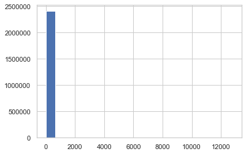

```python
plt.hist(data = df_2019, x = 'distance_km', bins = 20 );
```

```python
df_2019.distance_km.describe()
```

```
count    2.407259e+06
mean     2.062629e+00
std      6.851395e+01
min      0.000000e+00
25%      9.300000e-01
50%      1.450000e+00
75%      2.230000e+00
max      1.280334e+04
Name: distance_km, dtype: float64
```